# Homework3

Caitlin Sutherland

04/02/2020

### Part I - ANOVAs

**1. Bring in the Killarney data.**

```r
kill.dat=read.csv("Killarney.csv")
```

**2. Make a box plot of species diversity by lake status. From the boxplot does it look like there are any differences in plankton diversity among the lake types?**

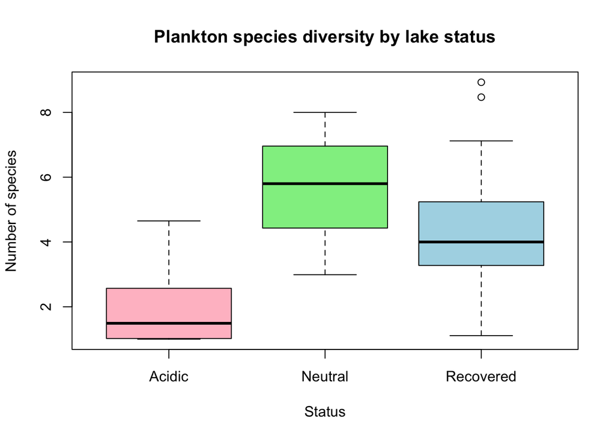

```r
plot(kill.dat$status,kill.dat$Diversity,main="Plankton species diversity by lake status",xlab="Status",ylab="Number of species",col=c("pink","lightgreen","lightblue"))
```

Based on the boxplot, the acidic lakes have a lower number of plankton species. Neutral lakes have the highest mean number of plankton species.

**3. Run an ANOVA to test for difference in species diversity among the three lake types. Display the summary output.**

```r
kill.anova=aov(kill.dat$Diversity~kill.dat$status)
summary(kill.anova)
```

```
##                 Df Sum Sq Mean Sq F value   Pr(>F)
## kill.dat$status  2  97.41   48.70   16.41 5.43e-06 ***
## Residuals       42 124.68    2.97
## ---
## Signif. codes:  0 '***' 0.001 '**' 0.01 '*' 0.05 '.' 0.1 ' ' 1
```

**4. What is the appropriate null hypothesis for the ANOVA?**

Null: There is no variance among groups (lake status does not affect plankton diversity).

Alternate: There is variance among groups (lake status affects plankton diversity).

**6. Did species diversity differ among these three lake types?**

Yes, species diversity differed among these three lake types.

**7. To determine which groups were significantly different from each other, run the appropriate follow-up test (Tukey tests). Provide output.**

```r
TukeyHSD(kill.anova)
```

```
##   Tukey multiple comparisons of means
##     95% family-wise confidence level
##
## Fit: aov(formula = kill.dat$Diversity ~ kill.dat$status)
##
## $`kill.dat$status`
##                        diff       lwr      upr     p adj
## Neutral-Acidic     3.603068  1.874854 5.331282 0.0000253
## Recovered-Acidic   2.418485  1.016843 3.820127 0.0004023
## Recovered-Neutral -1.184583 -3.017179 0.648012 0.2695118
```

**8. Based on your follow-up test, which groups are significantly different from one another?**

Based on the Tukey test, the Neutral and Acidic groups are significantly different and the Recovered and Acidic groups are significantly different (because the p value for both of these sets is < 0.05).

**9. Does the Killarney dataset meet the assumptions required for an ANOVA? Perform a Shapiro-Wilk test to examine if the residuals of the fitted model are normally distributed and Levene’s test to test for homogeneity of variances.**

```r
shapiro.test(kill.dat$Diversity)
```

```
##
##  Shapiro-Wilk normality test
##
## data:  kill.dat$Diversity
## W = 0.91031, p-value = 0.002016
```

The p-value returned by the S-W normality test is 0.002016, which is less than 0.05. This indicates that the data is not normally distributed.

```r
library(car)
leveneTest(kill.dat$Diversity,kill.dat$status)
```

```
## Levene's Test for Homogeneity of Variance (center = median)
##       Df F value Pr(>F)
## group  2  0.9977 0.3773
##       42
```

The p-value returned by the Levene’s test is 0.3773, which is greater than 0.05. This indicates that there is no significant difference between the group variances.

Overall, the Killarney dataset does not meet the assumption of normally distributed residuals (as returned by the S-W test) but does met the assumption of homoscedasticity (as returned by the Levene’s test).

**10. Run a two-factor ANOVA in R to determine if the number of cancer cases depends on alcohol consumption, tobacco consumption, or their interaction.**

**a) Provide an ANOVA table from the analysis.**

```r
esoph=read.csv("esoph.csv")
esoph.dat=aov(esoph$ncases~esoph$Alcohol*esoph$Tobacco)
summary(esoph.dat)
```

```
##                             Df Sum Sq Mean Sq F value Pr(>F)
## esoph$Alcohol                3   46.9  15.624   2.085  0.110
## esoph$Tobacco                3   41.5  13.846   1.848  0.146
## esoph$Alcohol:esoph$Tobacco  9   31.5   3.501   0.467  0.892
## Residuals                   72  539.5   7.494
```

**b) What is your conclusion about the effects of alcohol and tobacco based on this analysis?**

Since the P value for each factor (alcohol, tobacco, and alcohol+tobacco) is > 0.05, we can conclude that none of these factors affect the rate of esophageal cancer in patients.

**11. The previous analysis did not include age as a factor. Run a two-factor ANOVA to determine if the number of cases of esophageal cancer depend on age, tobacco use or their interaction.**

**a) Provide an ANOVA table from the analysis.**

```r
esoph.dat2=aov(esoph$ncases~esoph$Age*esoph$Tobacco)
summary(esoph.dat2)
```

```
##                         Df Sum Sq Mean Sq F value  Pr(>F)
## esoph$Age                5 261.20   52.24  12.826 1.2e-08 ***
## esoph$Tobacco            3  52.97   17.66   4.335 0.00763 **
## esoph$Age:esoph$Tobacco 15  84.62    5.64   1.385 0.18215
## Residuals               64 260.67    4.07
## ---
## Signif. codes:  0 '***' 0.001 '**' 0.01 '*' 0.05 '.' 0.1 ' ' 1
```

**b) Run a Tukey test to determine which groups are significantly different.**

```r
TukeyHSD(esoph.dat2)
```

```
##   Tukey multiple comparisons of means
##     95% family-wise confidence level
##
## Fit: aov(formula = esoph$ncases ~ esoph$Age * esoph$Tobacco)
##
## $`esoph$Age`
##                   diff        lwr        upr     p adj
## 35-44-25-34  0.5333333 -1.6316077  2.6982744 0.9783189
## 45-54-25-34  2.8083333  0.6774880  4.9391787 0.0033564
## 55-64-25-34  4.6833333  2.5524880  6.8141787 0.0000002
## 65-74-25-34  3.6000000  1.4350590  5.7649410 0.0001028
## 75+-25-34    1.1151515 -1.2383875  3.4686905 0.7316114
## 45-54-35-44  2.2750000  0.1441547  4.4058453 0.0296780
## 55-64-35-44  4.1500000  2.0191547  6.2808453 0.0000044
## 65-74-35-44  3.0666667  0.9017256  5.2316077 0.0013005
## 75+-35-44    0.5818182 -1.7717208  2.9353572 0.9779839
## 55-64-45-54  1.8750000 -0.2211951  3.9711951 0.1053407
## 65-74-45-54  0.7916667 -1.3391787  2.9225120 0.8830192
## 75+-45-54   -1.6931818 -4.0153959  0.6290322 0.2794932
## 65-74-55-64 -1.0833333 -3.2141787  1.0475120 0.6695191
## 75+-55-64   -3.5681818 -5.8903959 -1.2459678 0.0003880
## 75+-65-74   -2.4848485 -4.8383875 -0.1313095 0.0325950
##
## $`esoph$Tobacco`
##                       diff       lwr        upr     p adj
## 10-19-0-9g/day -0.83333333 -2.370109  0.7034420 0.4853668
## 20-29-0-9g/day -1.85739899 -3.469183 -0.2456155 0.0175826
## 30+-0-9g/day   -1.80648990 -3.418273 -0.1947064 0.0220542
## 20-29-10-19    -1.02406566 -2.635849  0.5877179 0.3446841
## 30+-10-19      -0.97315657 -2.584940  0.6386270 0.3900235
## 30+-20-29       0.05090909 -1.632544  1.7343621 0.9998160
##
## $`esoph$Age:esoph$Tobacco`
##                                        diff          lwr         upr     p adj
## 35-44:0-9g/day-25-34:0-9g/day  5.000000e-01  -4.92250361  5.92250361 1.0000000
## 45-54:0-9g/day-25-34:0-9g/day  3.500000e+00  -1.92250361  8.92250361 0.7044917
## 55-64:0-9g/day-25-34:0-9g/day  6.250000e+00   0.82749639 11.67250361 0.0086982
## 65-74:0-9g/day-25-34:0-9g/day  7.750000e+00   2.32749639 13.17250361 0.0002200
## 75+:0-9g/day-25-34:0-9g/day    1.500000e+00  -3.92250361  6.92250361 0.9999909
## 25-34:10-19-25-34:0-9g/day     2.500000e-01  -5.17250361  5.67250361 1.0000000
```

[output cut: 255 more lines]

```
## 35-44:30+-25-34:30+            1.017704e-16  -5.85697331  5.85697331 1.0000000
## 45-54:30+-25-34:30+            2.750000e+00  -2.67250361  8.17250361 0.9536697
## 55-64:30+-25-34:30+            4.000000e+00  -1.42250361  9.42250361 0.4540368
## 65-74:30+-25-34:30+            6.666667e-01  -5.19030664  6.52363997 1.0000000
## 75+:30+-25-34:30+              1.000000e+00  -5.64118349  7.64118349 1.0000000
## 45-54:30+-35-44:30+            2.750000e+00  -3.10697331  8.60697331 0.9791234
## 55-64:30+-35-44:30+            4.000000e+00  -1.85697331  9.85697331 0.6036644
## 65-74:30+-35-44:30+            6.666667e-01  -5.59470117  6.92803451 1.0000000
## 75+:30+-35-44:30+              1.000000e+00  -6.00042206  8.00042206 1.0000000
## 55-64:30+-45-54:30+            1.250000e+00  -4.17250361  6.67250361 0.9999997
## 65-74:30+-45-54:30+           -2.083333e+00  -7.94030664  3.77363997 0.9994407
## 75+:30+-45-54:30+             -1.750000e+00  -8.39118349  4.89118349 0.9999962
## 65-74:30+-55-64:30+           -3.333333e+00  -9.19030664  2.52363997 0.8730024
## 75+:30+-55-64:30+             -3.000000e+00  -9.64118349  3.64118349 0.9864955
## 75+:30+-65-74:30+              3.333333e-01  -6.66708873  7.33375539 1.0000000
```

**c) What is your conclusion about the effect of age and tobacco use based on this analysis?**

Based on this analysis, age and the use of tobacco both affect the rate of esophageal cancer in patients (the p value for both factors is < 0.05). In addition, the interaction of these two factors does not affect the rate of esophageal cancer in patients (the p value is > 0.05).

The Tukey test indicated that the following age groups were significantly different from each other (p < 0.05): 25-34 & 45-54, 25-34 & 55-64, and 25-34 & 65-74. However, the 25-34 & 35-44 groups and the 25-34 & 75+ year groups were not significantly different from each other. This seems to indicate that rate of esophageal cancer changes with age (beyond 44 years) but stops changing betond 75 years of age. A similar pattern is associated with the 35-44 age group: it is significantly different from 45-54, 55-64, and 65-74 but not significantly different from 75+. The other two age groups that were significantly different from each other were 55-64 & 75+ and 65-74 and 75+.

**12. How do age and alcohol consumption influence esophageal cancer rates? Run a two-factor ANOVA to test whether the number of esophageal cancer cases depend on age, alcohol consuption or their interaction.**

**a) Provide an ANOVA table from the analysis.**

```r
esoph.dat3=aov(esoph$ncases~esoph$Age*esoph$Alcohol)
summary(esoph.dat3)
```

```
##                         Df Sum Sq Mean Sq F value   Pr(>F)
## esoph$Age                5  261.2   52.24  14.048 2.89e-09 ***
## esoph$Alcohol            3   52.7   17.57   4.723  0.00486 **
## esoph$Age:esoph$Alcohol 15  107.6    7.17   1.928  0.03633 *
## Residuals               64  238.0    3.72
## ---
## Signif. codes:  0 '***' 0.001 '**' 0.01 '*' 0.05 '.' 0.1 ' ' 1
```

**b) Make an interaction plot to plot the results.**

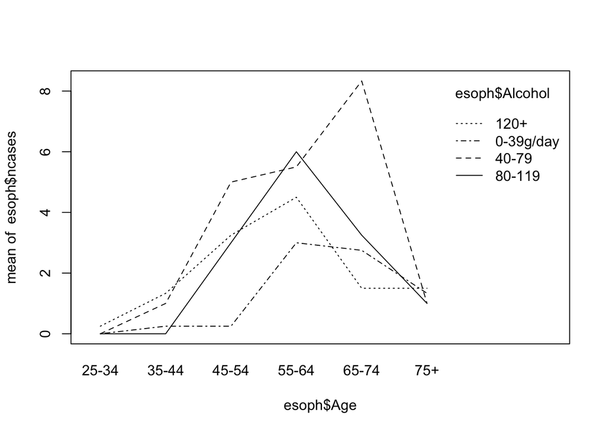

```r
interaction.plot(esoph$Age,esoph$Alcohol,esoph$ncases,legend=T)
```

**c) What is your conclusion about the effects of age and alcohol consumption based on this analysis?**

Based on the ANOVA analysis, age and alcohol use both have a significant effect on esophageal cancer rates (p < 0.05). In addition, the interaction of these two factors also has an effect on esophageal cancer rates (p < 0.05).

The interaction plot further illustrates these relationships. For all levels of alcohol consumption, the number of cases of esophageal cancer increase with age, peak at 55-64 or 65-74 years, and then decline (presumably since the overall number of individuals decreases due to deaths from all causes).

### Part II - Regression and Correlation

**13. Exercise using ‘mtcars’, a built-in dataset in R.**

```r
cars=mtcars
cars
```

```
##                      mpg cyl  disp  hp drat    wt  qsec vs am gear carb
## Mazda RX4           21.0   6 160.0 110 3.90 2.620 16.46  0  1    4    4
## Mazda RX4 Wag       21.0   6 160.0 110 3.90 2.875 17.02  0  1    4    4
## Datsun 710          22.8   4 108.0  93 3.85 2.320 18.61  1  1    4    1
## Hornet 4 Drive      21.4   6 258.0 110 3.08 3.215 19.44  1  0    3    1
## Hornet Sportabout   18.7   8 360.0 175 3.15 3.440 17.02  0  0    3    2
## Valiant             18.1   6 225.0 105 2.76 3.460 20.22  1  0    3    1
## Duster 360          14.3   8 360.0 245 3.21 3.570 15.84  0  0    3    4
## Merc 240D           24.4   4 146.7  62 3.69 3.190 20.00  1  0    4    2
## Merc 230            22.8   4 140.8  95 3.92 3.150 22.90  1  0    4    2
## Merc 280            19.2   6 167.6 123 3.92 3.440 18.30  1  0    4    4
## Merc 280C           17.8   6 167.6 123 3.92 3.440 18.90  1  0    4    4
## Merc 450SE          16.4   8 275.8 180 3.07 4.070 17.40  0  0    3    3
## Merc 450SL          17.3   8 275.8 180 3.07 3.730 17.60  0  0    3    3
## Merc 450SLC         15.2   8 275.8 180 3.07 3.780 18.00  0  0    3    3
## Cadillac Fleetwood  10.4   8 472.0 205 2.93 5.250 17.98  0  0    3    4
## Lincoln Continental 10.4   8 460.0 215 3.00 5.424 17.82  0  0    3    4
## Chrysler Imperial   14.7   8 440.0 230 3.23 5.345 17.42  0  0    3    4
## Fiat 128            32.4   4  78.7  66 4.08 2.200 19.47  1  1    4    1
## Honda Civic         30.4   4  75.7  52 4.93 1.615 18.52  1  1    4    2
## Toyota Corolla      33.9   4  71.1  65 4.22 1.835 19.90  1  1    4    1
## Toyota Corona       21.5   4 120.1  97 3.70 2.465 20.01  1  0    3    1
## Dodge Challenger    15.5   8 318.0 150 2.76 3.520 16.87  0  0    3    2
## AMC Javelin         15.2   8 304.0 150 3.15 3.435 17.30  0  0    3    2
## Camaro Z28          13.3   8 350.0 245 3.73 3.840 15.41  0  0    3    4
## Pontiac Firebird    19.2   8 400.0 175 3.08 3.845 17.05  0  0    3    2
## Fiat X1-9           27.3   4  79.0  66 4.08 1.935 18.90  1  1    4    1
## Porsche 914-2       26.0   4 120.3  91 4.43 2.140 16.70  0  1    5    2
## Lotus Europa        30.4   4  95.1 113 3.77 1.513 16.90  1  1    5    2
## Ford Pantera L      15.8   8 351.0 264 4.22 3.170 14.50  0  1    5    4
## Ferrari Dino        19.7   6 145.0 175 3.62 2.770 15.50  0  1    5    6
## Maserati Bora       15.0   8 301.0 335 3.54 3.570 14.60  0  1    5    8
## Volvo 142E          21.4   4 121.0 109 4.11 2.780 18.60  1  1    4    2
```

**a) Make a scatterplot of weight vs fuel mileage. Does fuel mileage seem to depend on weight?**

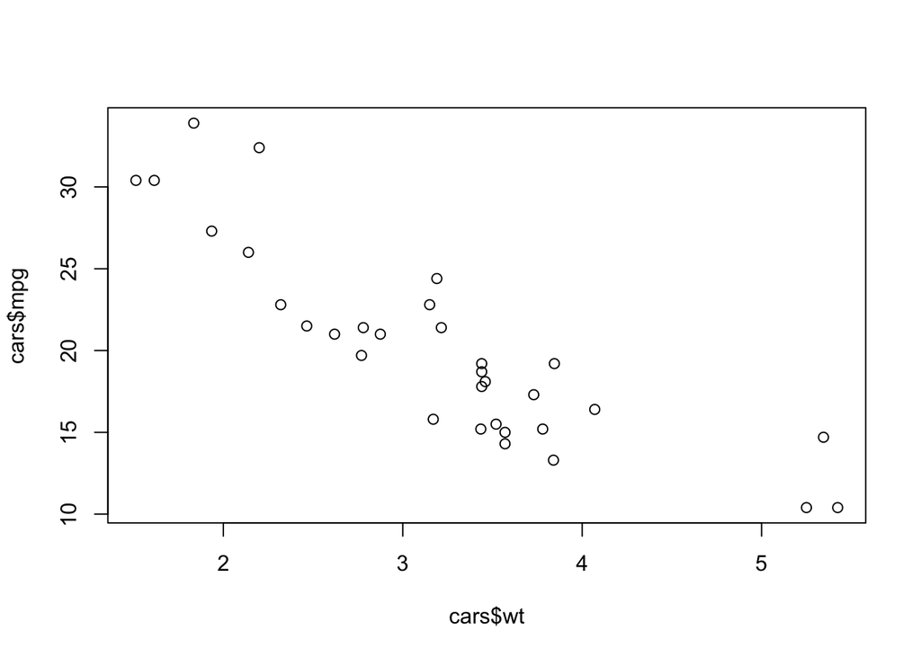

```r
plot(cars$wt,cars$mpg)
```

Fuel mileage seems to be related to weight; it appears that as the car’s weight increases its mileage decreases.

**b) Perform a linear regression to determine if weight has an impact on fuel mileage.**

```r
car.mpg=glm(cars$mpg~cars$wt)
car.mpg
```

```
##
## Call:  glm(formula = cars$mpg ~ cars$wt)
##
## Coefficients:
## (Intercept)      cars$wt
##      37.285       -5.344
##
## Degrees of Freedom: 31 Total (i.e. Null);  30 Residual
## Null Deviance:       1126
## Residual Deviance: 278.3     AIC: 166
```

**c) Add a blue line to the scatterplot indicating the fit of the linear regression. What is the equation of this line based on linear regression results?**

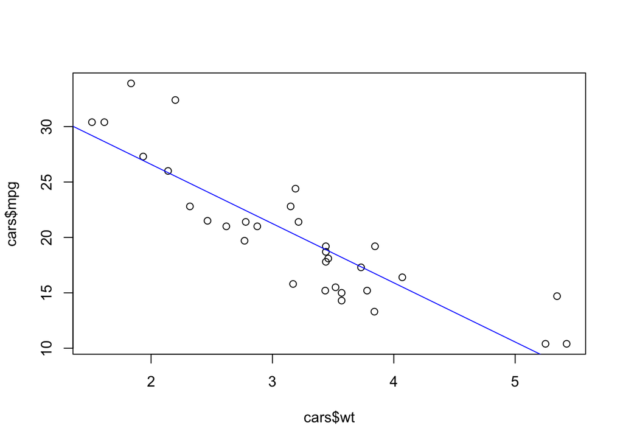

```r
plot(cars$wt,cars$mpg)
abline(car.mpg,col="blue")
```

```r
summary.lm(car.mpg)
```

```
##
## Call:
## glm(formula = cars$mpg ~ cars$wt)
##
## Residuals:
##     Min      1Q  Median      3Q     Max
## -4.5432 -2.3647 -0.1252  1.4096  6.8727
##
## Coefficients:
##             Estimate Std. Error t value Pr(>|t|)
## (Intercept)  37.2851     1.8776  19.858  < 2e-16 ***
## cars$wt      -5.3445     0.5591  -9.559 1.29e-10 ***
## ---
## Signif. codes:  0 '***' 0.001 '**' 0.01 '*' 0.05 '.' 0.1 ' ' 1
##
## Residual standard error: 3.046 on 30 degrees of freedom
## Multiple R-squared:  0.7528, Adjusted R-squared:  0.7446
## F-statistic: 91.38 on 1 and 30 DF,  p-value: 1.294e-10
```

The equation of this line is: y = -5.3445x + 37.2851.

**d) Is gas mileage significantly related to car weight? Provide the p-value from the regression results.**

Yes, gas mileage is significantly related to car weight (p value from regression = 1.29e-10, which is < 0.05).

**14. a) Make a scatterplot of horsepower vs quarter-mile time. Does quarter-mile time seem to depend on horsepower?**

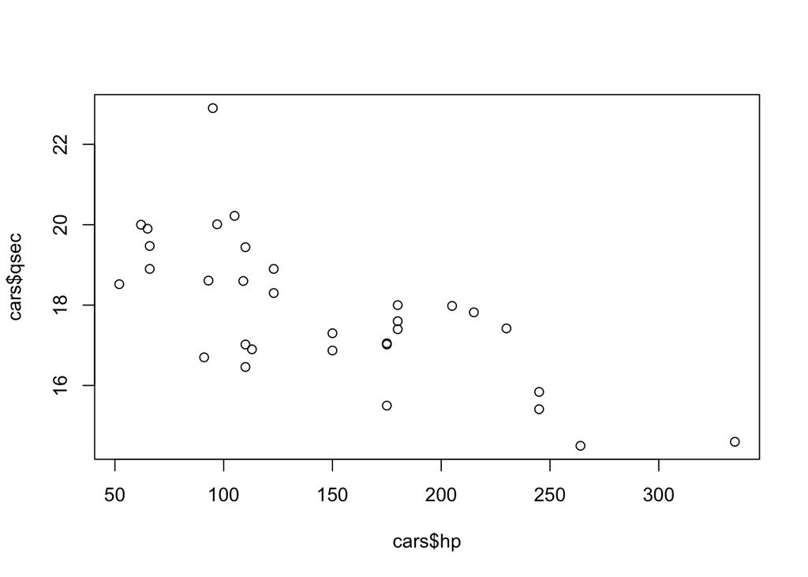

```r
plot(cars$hp,cars$qsec)
```

Quarter mile time does seem to depend on a car’s horsepower; as the horsepower increases, the quarter mile time decreases.

**b) Perform a linear regression to determine if horsepower has an impact on quarter mile time.**

```r
car.hp=glm(cars$qsec~cars$hp)
car.hp
```

```
##
## Call:  glm(formula = cars$qsec ~ cars$hp)
##
## Coefficients:
## (Intercept)      cars$hp
##    20.55635     -0.01846
##
## Degrees of Freedom: 31 Total (i.e. Null);  30 Residual
## Null Deviance:       98.99
## Residual Deviance: 49.34     AIC: 110.7
```

**c) Add a blue line to the scatterplot indicating the fit of the linear regression. What is the equation of this line based on linear regression results?**

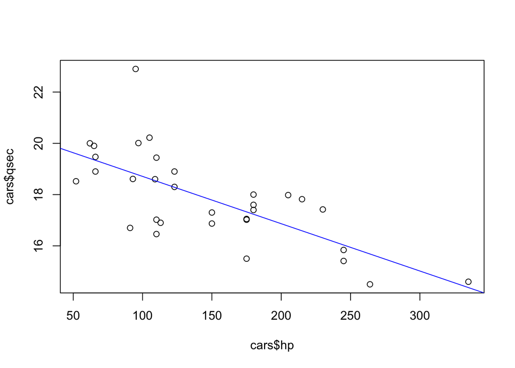

```r
plot(cars$hp,cars$qsec)
abline(car.hp,col="blue")
```

```r
summary.lm(car.hp)
```

```
##
## Call:
## glm(formula = cars$qsec ~ cars$hp)
##
## Residuals:
##     Min      1Q  Median      3Q     Max
## -2.1766 -0.6975  0.0348  0.6520  4.0972
##
## Coefficients:
##              Estimate Std. Error t value Pr(>|t|)
## (Intercept) 20.556354   0.542424  37.897  < 2e-16 ***
## cars$hp     -0.018458   0.003359  -5.495 5.77e-06 ***
## ---
## Signif. codes:  0 '***' 0.001 '**' 0.01 '*' 0.05 '.' 0.1 ' ' 1
##
## Residual standard error: 1.282 on 30 degrees of freedom
## Multiple R-squared:  0.5016, Adjusted R-squared:  0.485
## F-statistic: 30.19 on 1 and 30 DF,  p-value: 5.766e-06
```

The equation of this line is: y = -0.018458x + 20.556354.

**d) What would be the quarter mile time for a car with 300 HP according to the regression fit?**

The quarter mile time for a car with 300 HP would be y = -0.018458*300 + 20.556354, which results in y = 15.02 sec.

**e) Is quarter mile time significantly related to a car’s horsepower? Provide the p-value from regression results.**

Horsepower does seem to have a significant relationship with quarter mile time (p = 5.77e-06 which is < 0.05).

**f) Use the gvlma function to determine if the assumptions of a linear regression were met. Provide the output from the analysis. Did this data meet the required assumptions?**

```r
library(gvlma)
gvlma(lm(car.hp))
```

```
##
## Call:
## lm(formula = car.hp)
##
## Coefficients:
## (Intercept)      cars$hp
##    20.55635     -0.01846
##
##
## ASSESSMENT OF THE LINEAR MODEL ASSUMPTIONS
## USING THE GLOBAL TEST ON 4 DEGREES-OF-FREEDOM:
## Level of Significance =  0.05
##
## Call:
##  gvlma(x = lm(car.hp))
##
##                       Value p-value                   Decision
## Global Stat        8.148631 0.08628    Assumptions acceptable.
## Skewness           2.876131 0.08990    Assumptions acceptable.
## Kurtosis           4.338691 0.03726 Assumptions NOT satisfied!
## Link Function      0.001639 0.96771    Assumptions acceptable.
## Heteroscedasticity 0.932170 0.33430    Assumptions acceptable.
```

While the gvlma analysis indicates that the data does not meet the linear regression assumption for Kurtosis, the combined Global Stat test statistic (a combination of the four component tests: Skewness, Kurtosis, Link Function and Heteroscedasticity) indicates that overall the data meets the required assumptions.

**15. a) Find two variables that you think may be correlated.**

```r
trees=Loblolly
trees
```

```
##    height age Seed
## 1    4.51   3  301
## 15  10.89   5  301
## 29  28.72  10  301
## 43  41.74  15  301
## 57  52.70  20  301
## 71  60.92  25  301
## 2    4.55   3  303
## 16  10.92   5  303
## 30  29.07  10  303
## 44  42.83  15  303
## 58  53.88  20  303
## 72  63.39  25  303
## 3    4.79   3  305
## 17  11.37   5  305
```

[output cut: 70 more lines]

It is likely that the age and height of the trees in this dataset are correlated.

**b) Plot the relationship between the variables using a scatterplot.**

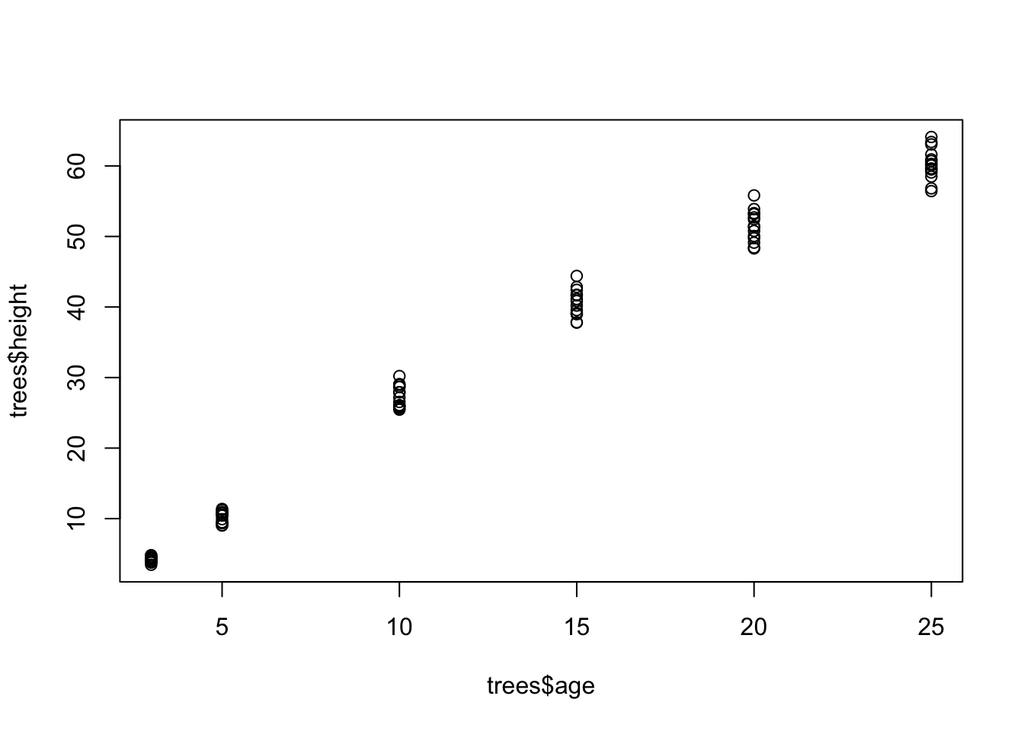

```r
plot(trees$age,trees$height)
```

```r
tree.fit=glm(trees$height~trees$age)
tree.fit
```

```
##
## Call:  glm(formula = trees$height ~ trees$age)
##
## Coefficients:
## (Intercept)    trees$age
##      -1.312        2.591
##
## Degrees of Freedom: 83 Total (i.e. Null);  82 Residual
## Null Deviance:       35470
## Residual Deviance: 712   AIC: 423.9
```

**c) Test for a correlation in R. What is the correlation coefficient?**

The Pearson’s correlation coefficient (r) will be calculated by taking the square root of the multiple R-squared value returned in the regression summary.

```r
summary.lm(tree.fit)
```

```
##
## Call:
## glm(formula = trees$height ~ trees$age)
##
## Residuals:
##     Min      1Q  Median      3Q     Max
## -7.0207 -2.1672 -0.4391  2.0539  6.8545
##
## Coefficients:
##             Estimate Std. Error t value Pr(>|t|)
## (Intercept) -1.31240    0.62183  -2.111   0.0379 *
## trees$age    2.59052    0.04094  63.272   <2e-16 ***
## ---
## Signif. codes:  0 '***' 0.001 '**' 0.01 '*' 0.05 '.' 0.1 ' ' 1
##
## Residual standard error: 2.947 on 82 degrees of freedom
## Multiple R-squared:  0.9799, Adjusted R-squared:  0.9797
## F-statistic:  4003 on 1 and 82 DF,  p-value: < 2.2e-16
```

```r
rvalue=sqrt(0.9799)
```

The multiple R-squared returned by the regression is 0.9799. This results in an r value of 0.989899. This indicates a very strong positive correlation between the two variables (tree height and tree age).

**d) Is the correlation significant? Provide the p-value from the test.**

The correlation is significant. The p value returned from the test is < 2e-16, which is < 0.05. We reject the null hypothesis that there is no correlation.